# Archvale Data Analysis

Nianyu Li

2023-06-09

# 1 Loading the data

```
## Rows: 1,657
## Columns: 4
## $ patient_id        <dbl> 2509, 2793, 3246, 3479, 4388, 5266, 5511, 8459, 1209…
## $ date_of_birth     <chr> "10-Jan-1964", "12-Dec-1995", "08-Mar-1984", "31-Jul…
## $ gender            <chr> "Female", "Female", "Male", "Female", "Female", "Fem…
## $ registration_date <chr> "18-Jul-2018", "02-Mar-2021", "11-Sep-2014", "31-Mar…
```

```
## Rows: 3,603
## Columns: 7
## $ patient_id                   <dbl> 521033, 705568, 734149, 734149, 734149, 7…
## $ date_of_birth                <chr> "01-Sep-71", "16-Jun-57", "23-Apr-68", "2…
## $ gender                       <chr> "Male", "Male", "Male", "Male", "Male", "…
## $ appointment_date             <chr> "14/11/22", "06/10/22", "01/08/22", "10/0…
## $ appointment_time             <time> 14:00:00, 11:10:00, 10:15:00, 10:00:00, …
## $ clinician                    <chr> "Advanced Nurse Practitioner", "General P…
## $ planned_appointment_duration <chr> "15", "10", "15", "10", "10", "10", "10",…
```

```
## Rows: 453
## Columns: 21
## $ patient_id <dbl> 2509, 4388, 12311, 12900, 15703, 17239, 17577, 17977, 18491…
## $ ast        <dbl> 0, 0, 0, 0, 1, 0, 0, 1, 1, 1, 1, 0, 0, 0, 0, 0, 0, 1, 0, 1,…
## $ af         <dbl> 0, 0, 0, 0, 0, 0, 0, 0, 0, 0, 0, 0, 0, 0, 0, 0, 0, 0, 0, 0,…
## $ can        <dbl> 0, 0, 0, 1, 0, 0, 0, 0, 0, 0, 0, 0, 0, 0, 0, 0, 0, 0, 0, 0,…
## $ chd        <dbl> 0, 0, 0, 1, 0, 1, 0, 0, 0, 0, 0, 0, 0, 0, 0, 0, 0, 0, 0, 0,…
## $ ckd        <dbl> 0, 1, 0, 1, 0, 0, 0, 0, 0, 0, 0, 0, 0, 0, 1, 0, 0, 0, 0, 0,…
## $ cop        <dbl> 0, 1, 0, 0, 1, 1, 0, 0, 1, 0, 0, 0, 0, 0, 0, 0, 0, 0, 0, 0,…
## $ dem        <dbl> 0, 0, 0, 0, 0, 0, 0, 0, 0, 0, 0, 0, 0, 0, 0, 0, 0, 0, 0, 0,…
## $ dep        <dbl> 0, 0, 0, 0, 0, 0, 0, 0, 0, 0, 0, 0, 0, 0, 0, 0, 0, 0, 0, 0,…
## $ dm         <dbl> 1, 1, 0, 0, 0, 0, 0, 0, 0, 0, 0, 1, 1, 1, 1, 0, 0, 0, 0, 0,…
## $ ep         <dbl> 0, 0, 0, 0, 0, 0, 0, 0, 0, 0, 0, 0, 0, 0, 0, 0, 0, 0, 0, 0,…
## $ hf         <dbl> 0, 0, 0, 0, 0, 0, 0, 0, 0, 0, 0, 0, 0, 0, 0, 0, 0, 0, 0, 0,…
## $ hyp        <dbl> 0, 1, 0, 1, 1, 0, 1, 0, 0, 0, 0, 0, 1, 0, 1, 1, 1, 0, 1, 1,…
## $ ld         <dbl> 0, 0, 1, 0, 0, 0, 0, 0, 0, 0, 0, 0, 0, 1, 0, 0, 0, 0, 0, 0,…
## $ mh         <dbl> 0, 0, 0, 1, 0, 0, 0, 0, 1, 0, 0, 0, 0, 0, 0, 0, 0, 0, 0, 0,…
## $ ndh        <dbl> 1, 0, 0, 0, 0, 0, 0, 0, 0, 0, 0, 0, 0, 0, 0, 0, 1, 0, 1, 0,…
## $ ost        <dbl> 0, 0, 0, 0, 0, 0, 0, 0, 0, 0, 0, 0, 0, 0, 0, 0, 0, 0, 0, 0,…
## $ pad        <dbl> 0, 0, 0, 1, 0, 0, 0, 0, 0, 0, 0, 0, 0, 0, 0, 0, 0, 1, 0, 0,…
## $ pc         <dbl> 0, 0, 0, 0, 0, 0, 0, 0, 0, 0, 0, 0, 0, 0, 0, 0, 0, 0, 0, 0,…
## $ ra         <dbl> 0, 0, 0, 0, 0, 0, 0, 0, 0, 0, 0, 0, 0, 0, 0, 0, 0, 1, 0, 0,…
## $ sti        <dbl> 0, 0, 0, 0, 1, 0, 0, 0, 0, 0, 0, 0, 0, 0, 0, 0, 0, 0, 0, 0,…
```

# 2 Data Preparation

## 2.1 Frequencies

Sum the number of consultations of each patients and join the table with `patient` table.

```r
#Count visit times of each patients
visit_n <-
  appointment %>%
  group_by(patient_id) %>%
  summarise(visit_n = n())

#Join the table with patients record
patients_n_visits <-
  left_join(x = patient,
            y = visit_n,
            by = "patient_id") %>%

  #change NA to 0 for the patients who have never visited GP
  mutate(visit_n = replace_na(visit_n,0)) %>%

  arrange(desc(visit_n)) %>%

  print()
```

```
## # A tibble: 1,657 × 5
##    patient_id date_of_birth gender registration_date visit_n
##         <dbl> <chr>         <chr>  <chr>               <int>
##  1     413591 31-Mar-1936   Female 31-Mar-1996            25
##  2     449175 25-Jul-1996   Female 08-Nov-1996            25
##  3     203029 18-Jul-1964   Female 28-Oct-2019            24
##  4     924706 18-Dec-1950   Female 31-Mar-1996            24
##  5     596712 12-Dec-1970   Female 06-May-1994            23
##  6     390794 11-Sep-1984   Female 31-Mar-1996            21
##  7     357148 31-Dec-1984   Female 06-Jan-2017            19
##  8     693562 29-Nov-1948   Female 15-Jan-1998            19
##  9     425567 18-Dec-1966   Male   31-Mar-1996            18
## 10     617753 17-Jul-1976   Female 02-May-2012            16
## # ℹ 1,647 more rows
```

## 2.2 Age

The age of the patient might affect their behaviour. As the time frame of the appoint record is not that long (only includes record of 2022-2023), we could assume the patient’s age is this year minus the year of their birthday, though not 100% accurate.

```r
patients_n_visits_1 <-  patients_n_visits %>%

  #convert character to date
  mutate(date_of_birth = dmy(date_of_birth)) %>%

  #calculate age
  mutate(age = year(today()) - year(date_of_birth)) %>%

  print()
```

```
## # A tibble: 1,657 × 6
##    patient_id date_of_birth gender registration_date visit_n   age
##         <dbl> <date>        <chr>  <chr>               <int> <dbl>
##  1     413591 1936-03-31    Female 31-Mar-1996            25    87
##  2     449175 1996-07-25    Female 08-Nov-1996            25    27
##  3     203029 1964-07-18    Female 28-Oct-2019            24    59
##  4     924706 1950-12-18    Female 31-Mar-1996            24    73
##  5     596712 1970-12-12    Female 06-May-1994            23    53
##  6     390794 1984-09-11    Female 31-Mar-1996            21    39
##  7     357148 1984-12-31    Female 06-Jan-2017            19    39
##  8     693562 1948-11-29    Female 15-Jan-1998            19    75
##  9     425567 1966-12-18    Male   31-Mar-1996            18    57
## 10     617753 1976-07-17    Female 02-May-2012            16    47
## # ℹ 1,647 more rows
```

## 2.3 Registration Cohort

Patients who registered after March 2023 might have a different behaviour due to the implementation of a marketing campign. Create a new variable to show the registration cohort of the patients: people who registered before March 2023 are classified as in the `Old` cohort, whereas after March 2023 belongs to `New` cohort.

```r
patients_n_visits_2 <-  patients_n_visits_1 %>%

  #convert character to date
  mutate(registration_date = dmy(registration_date)) %>%

  #create a new variable to show their registration cohort
  mutate(cohort = case_when(registration_date > "2023-03-01" ~ "New",
                            registration_date < "2023-03-01" ~ "Old")) %>%

  print()
```

```
## # A tibble: 1,657 × 7
##    patient_id date_of_birth gender registration_date visit_n   age cohort
##         <dbl> <date>        <chr>  <date>              <int> <dbl> <chr>
##  1     413591 1936-03-31    Female 1996-03-31             25    87 Old
##  2     449175 1996-07-25    Female 1996-11-08             25    27 Old
##  3     203029 1964-07-18    Female 2019-10-28             24    59 Old
##  4     924706 1950-12-18    Female 1996-03-31             24    73 Old
##  5     596712 1970-12-12    Female 1994-05-06             23    53 Old
##  6     390794 1984-09-11    Female 1996-03-31             21    39 Old
##  7     357148 1984-12-31    Female 2017-01-06             19    39 Old
##  8     693562 1948-11-29    Female 1998-01-15             19    75 Old
##  9     425567 1966-12-18    Male   1996-03-31             18    57 Old
## 10     617753 1976-07-17    Female 2012-05-02             16    47 Old
## # ℹ 1,647 more rows
```

## 2.4 Chronic Disease

Patients with chronic diseases visits GP regularly. Create a new variable called chronic_disease to show the number of disease the patient have.

```r
#convert the data to long format
chronicDisease_1 <- chronicDisease %>%
  pivot_longer(cols = -"patient_id",
               names_to = "disease",
               values_to = "yn") %>%

  group_by(patient_id) %>%
  summarise(n_disease = sum(yn))

patients_n_visits_3 <-

  #Join the chronic disease table with patients table
  left_join(x = patients_n_visits_2,
            y = chronicDisease_1,
            by = "patient_id") %>%

  #convert NA to 0
  mutate(n_disease = replace_na(n_disease,0)) %>%

  print()
```

```
## # A tibble: 1,657 × 8
##    patient_id date_of_birth gender registration_date visit_n   age cohort
##         <dbl> <date>        <chr>  <date>              <int> <dbl> <chr>
##  1     413591 1936-03-31    Female 1996-03-31             25    87 Old
##  2     449175 1996-07-25    Female 1996-11-08             25    27 Old
##  3     203029 1964-07-18    Female 2019-10-28             24    59 Old
##  4     924706 1950-12-18    Female 1996-03-31             24    73 Old
##  5     596712 1970-12-12    Female 1994-05-06             23    53 Old
##  6     390794 1984-09-11    Female 1996-03-31             21    39 Old
##  7     357148 1984-12-31    Female 2017-01-06             19    39 Old
##  8     693562 1948-11-29    Female 1998-01-15             19    75 Old
##  9     425567 1966-12-18    Male   1996-03-31             18    57 Old
## 10     617753 1976-07-17    Female 2012-05-02             16    47 Old
## # ℹ 1,647 more rows
## # ℹ 1 more variable: n_disease <dbl>
```

## 2.5 Average appointment time

```r
#Calculate the average appointment time for patients
app_time <- appointment %>%
  group_by(patient_id) %>%
  summarise(avg_time = mean(as.integer(planned_appointment_duration)))

#join it with the patients table
patients_n_visits_4 <- left_join(x = patients_n_visits_3,
                                 y = app_time,
                                 by = "patient_id") %>%

  #convert NA to 0
  mutate(avg_time = replace_na(avg_time,0)) %>%

  print()
```

```
## # A tibble: 1,657 × 9
##    patient_id date_of_birth gender registration_date visit_n   age cohort
##         <dbl> <date>        <chr>  <date>              <int> <dbl> <chr>
##  1     413591 1936-03-31    Female 1996-03-31             25    87 Old
##  2     449175 1996-07-25    Female 1996-11-08             25    27 Old
##  3     203029 1964-07-18    Female 2019-10-28             24    59 Old
##  4     924706 1950-12-18    Female 1996-03-31             24    73 Old
##  5     596712 1970-12-12    Female 1994-05-06             23    53 Old
##  6     390794 1984-09-11    Female 1996-03-31             21    39 Old
##  7     357148 1984-12-31    Female 2017-01-06             19    39 Old
##  8     693562 1948-11-29    Female 1998-01-15             19    75 Old
##  9     425567 1966-12-18    Male   1996-03-31             18    57 Old
## 10     617753 1976-07-17    Female 2012-05-02             16    47 Old
## # ℹ 1,647 more rows
## # ℹ 2 more variables: n_disease <dbl>, avg_time <dbl>
```

## 2.6 Average appointment intervals

```r
app_interval <- appointment %>%

  #convert character to date
  mutate(appointment_date = dmy(appointment_date)) %>%

  #group by patients
  group_by(patient_id) %>%

  #calculate average interval
  summarise(app_interval_sum = max(appointment_date) - min(appointment_date),
            visit_n = n()) %>%

  mutate(app_interval = app_interval_sum/visit_n,
         app_interval_int = as.numeric(app_interval)) %>%

  #arrange the data
  arrange(desc(app_interval)) %>%

  select(patient_id, app_interval_int)

  #Join it with patients table and omit NAs
patients_n_visits_5 <- left_join(x = patients_n_visits_4,
                                 y = app_interval,
                                 by = "patient_id") %>%

  #convert NA to 0
  mutate(app_interval_int = replace_na(app_interval_int,0)) %>%

  print()
```

```
## # A tibble: 1,657 × 10
##    patient_id date_of_birth gender registration_date visit_n   age cohort
##         <dbl> <date>        <chr>  <date>              <int> <dbl> <chr>
##  1     413591 1936-03-31    Female 1996-03-31             25    87 Old
##  2     449175 1996-07-25    Female 1996-11-08             25    27 Old
##  3     203029 1964-07-18    Female 2019-10-28             24    59 Old
##  4     924706 1950-12-18    Female 1996-03-31             24    73 Old
##  5     596712 1970-12-12    Female 1994-05-06             23    53 Old
##  6     390794 1984-09-11    Female 1996-03-31             21    39 Old
##  7     357148 1984-12-31    Female 2017-01-06             19    39 Old
##  8     693562 1948-11-29    Female 1998-01-15             19    75 Old
##  9     425567 1966-12-18    Male   1996-03-31             18    57 Old
## 10     617753 1976-07-17    Female 2012-05-02             16    47 Old
## # ℹ 1,647 more rows
## # ℹ 3 more variables: n_disease <dbl>, avg_time <dbl>, app_interval_int <dbl>
```

# 3 Data Analysis

We make the following assumptions to identify the inappropriate users of GP services:

1. They are frequent users of GP services.
2. They are associate with potential inappropriate usage.

## 3.1 Identify Frequent Patients

### 3.1.1 General Approach

Calculate the patient’s GP frequencies to identify the frequent patients.

```r
patients_frequency <- patients_n_visits_5 %>%

  #group the patients by their frequencies
  group_by(visit_n) %>%

  #count the total number of patients and visits in each group
  summarise(patient_n = n(),
            visit_total_n = sum(visit_n)) %>%

  #calculate the percentages
  mutate(patient_pct = round(patient_n/sum(patient_n)*100,2),
         visit_pct = round(visit_total_n/sum(visit_total_n)*100,2)) %>%

  #calculate the cumulative percentages
  arrange(desc(visit_n)) %>%
  mutate(patient_cumpct = cumsum(patient_pct),
         visit_cumpct = cumsum(visit_pct)) %>%

  print()
```

```
## # A tibble: 23 × 7
##    visit_n patient_n visit_total_n patient_pct visit_pct patient_cumpct
##      <int>     <int>         <int>       <dbl>     <dbl>          <dbl>
##  1      25         2            50        0.12      1.4            0.12
##  2      24         2            48        0.12      1.35           0.24
##  3      23         1            23        0.06      0.65           0.3
##  4      21         1            21        0.06      0.59           0.36
##  5      19         2            38        0.12      1.07           0.48
##  6      18         1            18        0.06      0.5            0.54
##  7      16         3            48        0.18      1.35           0.72
##  8      15         5            75        0.3       2.1            1.02
##  9      14         5            70        0.3       1.96           1.32
## 10      13         8           104        0.48      2.92           1.8
## # ℹ 13 more rows
## # ℹ 1 more variable: visit_cumpct <dbl>
```

```r
#save the tibble as an excel
#write.xlsx(patients_frequency, "patients_frequency.xlsx")
```

From the cumulative percentages, we can tell that patients who visit the GP more than 6 times account for only about 13% of total patients, but more than 50% of the consultations. Therefore, we name this group as `Frequent` and the other as `Non-frequent`.

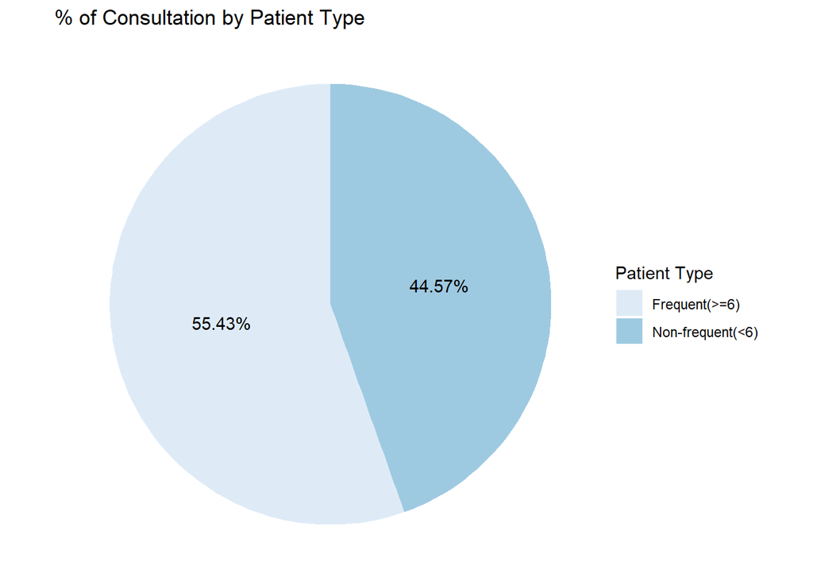

```r
patients_frequency %>%

  #summarize percentage of visits of frequent and non-frequent patients

  mutate(patient_type = case_when(visit_n >= 6 ~ "Frequent(>=6)",
                                  visit_n < 6 ~ "Non-frequent(<6)")) %>%

  group_by(patient_type) %>%

  summarise(pct_visit_total = sum(visit_pct),
            pct_patient_total = sum(patient_pct)) %>%

  ggplot()+

  aes(x = '',
      y = pct_visit_total,
      fill = patient_type) +

  geom_col(position = "stack") +

  scale_fill_brewer()+

  geom_text(aes(label = paste0(pct_visit_total,"%")),
            position = position_stack(vjust = 0.5)) +

  coord_polar("y")+

  theme_void()+

  theme(axis.ticks = element_blank(),
        axis.text = element_blank())+

  labs(title = "% of Consultation by Patient Type",
       x = NULL, y = NULL,
       fill = "Patient Type")
```

### 3.1.2 Testing the hypothesis

Test the hypothesis: does GP frequencies have to do with Age/Gender/Chronic Disease/Registration Cohort. If there is a relationship, we might take that into consideration when we decide whether the patient has an appropriate clinical need.

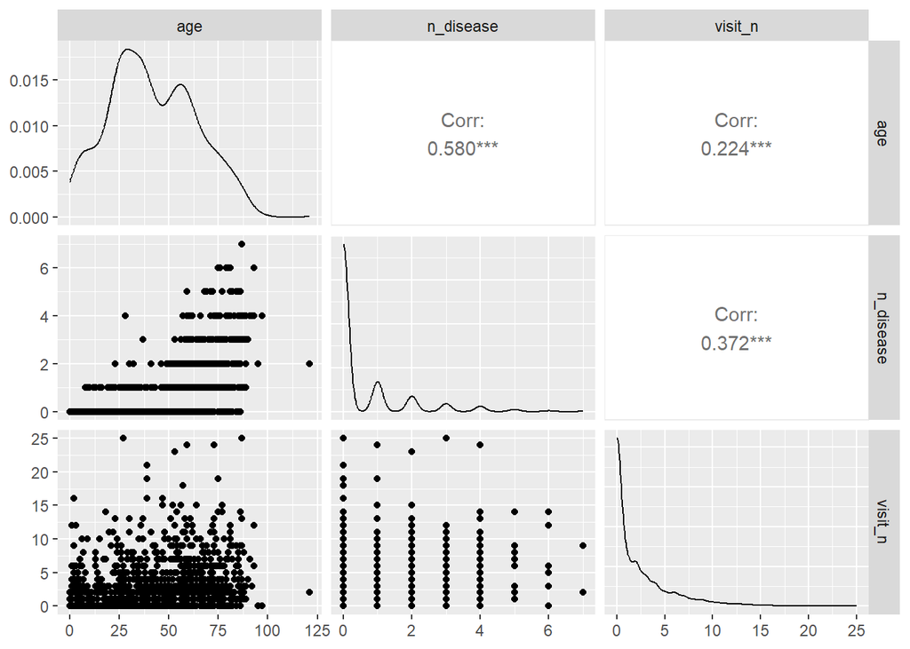

```r
patients_n_visits_3 %>%
  select(age, n_disease, visit_n) %>%
  ggpairs()
```

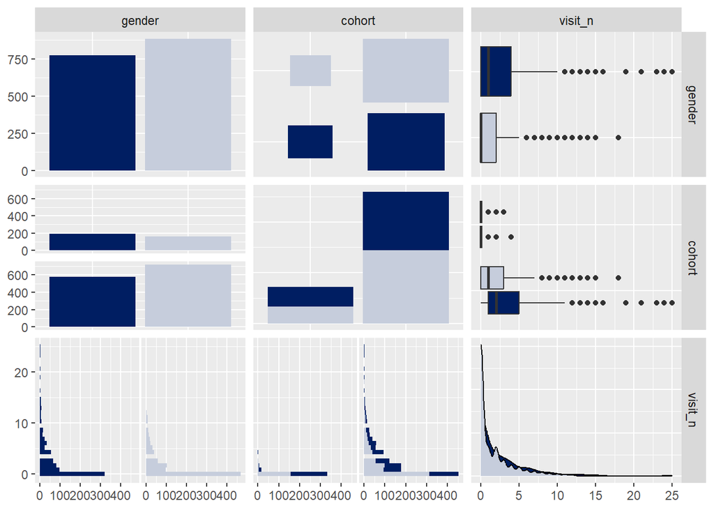

```r
patients_n_visits_3 %>%
  select(gender, cohort, visit_n) %>%
  ggpairs(aes(fill = gender))+
  scale_fill_manual(values = c("#001e62","#c6cddc"))
```

We can tell that Age and Chronic Disease have significant positive correlations with frequency of consultations. It also varies in Gender and Registration Cohort. Female tends to have higher number of consultations. New cohort tends to have lower number of consultations.

### 3.1.3 Refined Approach: Frequent patients by segments

People in different age/gender/registration cohort behave differently. Thus, different criteria is used to identify frequent patients.

#### 3.1.3.1 Gender

```r
#Filter data for just female
patients_frequency_f <- patients_n_visits_5 %>%

  filter(gender == "Female") %>%

  #group the patients by their frequencies
  group_by(visit_n) %>%

  #count the total number of patients and visits in each group
  summarise(patient_n = n(),
            visit_total_n = sum(visit_n)) %>%

  #calculate the percentages
  mutate(patient_pct = round(patient_n/sum(patient_n)*100,2),
         visit_pct = round(visit_total_n/sum(visit_total_n)*100,2)) %>%

  #calculate the cumulative percentages
  arrange(desc(visit_n)) %>%
  mutate(patient_cumpct = cumsum(patient_pct),
         visit_cumpct = cumsum(visit_pct)) %>%

  print()
```

```
## # A tibble: 22 × 7
##    visit_n patient_n visit_total_n patient_pct visit_pct patient_cumpct
##      <int>     <int>         <int>       <dbl>     <dbl>          <dbl>
##  1      25         2            50        0.26      2.44           0.26
##  2      24         2            48        0.26      2.35           0.52
##  3      23         1            23        0.13      1.12           0.65
##  4      21         1            21        0.13      1.03           0.78
##  5      19         2            38        0.26      1.86           1.04
##  6      16         3            48        0.39      2.35           1.43
##  7      15         4            60        0.52      2.93           1.95
##  8      14         4            56        0.52      2.74           2.47
##  9      13         7            91        0.91      4.45           3.38
## 10      12         5            60        0.65      2.93           4.03
## # ℹ 12 more rows
## # ℹ 1 more variable: visit_cumpct <dbl>
```

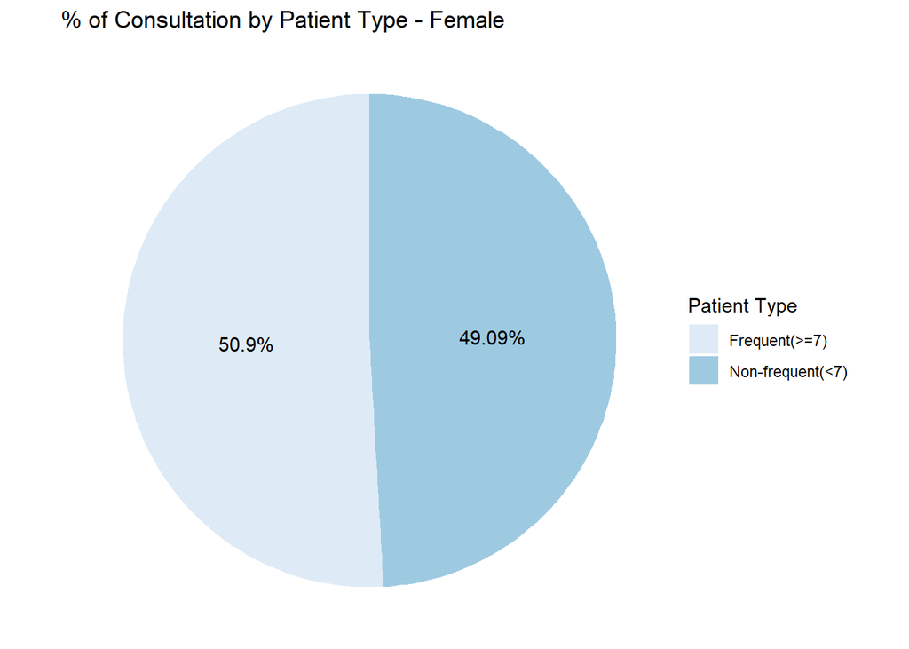

```r
patients_frequency_f %>%

  #summarize percentage of visits of frequent and non-frequent patients

  mutate(patient_type = case_when(visit_n >= 7 ~ "Frequent(>=7)",
                                  visit_n < 7 ~ "Non-frequent(<7)")) %>%

  group_by(patient_type) %>%

  summarise(pct_visit_total = sum(visit_pct),
            pct_patient_total = sum(patient_pct)) %>%

  ggplot()+

  aes(x = '',
      y = pct_visit_total,
      fill = patient_type) +

  geom_col(position = "stack") +

  scale_fill_brewer()+

  geom_text(aes(label = paste0(pct_visit_total,"%")),
            position = position_stack(vjust = 0.5)) +

  coord_polar("y")+

  theme_void()+

  theme(axis.ticks = element_blank(),
        axis.text = element_blank())+

  labs(title = "% of Consultation by Patient Type - Female",
       x = NULL, y = NULL,
       fill = "Patient Type")
```

```r
#Filter data for just male
patients_frequency_m <- patients_n_visits_5 %>%

  filter(gender == "Male") %>%

  #group the patients by their frequencies
  group_by(visit_n) %>%

  #count the total number of patients and visits in each group
  summarise(patient_n = n(),
            visit_total_n = sum(visit_n)) %>%

  #calculate the percentages
  mutate(patient_pct = round(patient_n/sum(patient_n)*100,2),
         visit_pct = round(visit_total_n/sum(visit_total_n)*100,2)) %>%

  #calculate the cumulative percentages
  arrange(desc(visit_n)) %>%
  mutate(patient_cumpct = cumsum(patient_pct),
         visit_cumpct = cumsum(visit_pct)) %>%

  print()
```

```
## # A tibble: 17 × 7
##    visit_n patient_n visit_total_n patient_pct visit_pct patient_cumpct
##      <int>     <int>         <int>       <dbl>     <dbl>          <dbl>
##  1      18         1            18        0.11      1.18           0.11
##  2      15         1            15        0.11      0.99           0.22
##  3      14         1            14        0.11      0.92           0.33
##  4      13         1            13        0.11      0.86           0.44
##  5      12         4            48        0.45      3.16           0.89
##  6      11         7            77        0.79      5.07           1.68
##  7      10         8            80        0.9       5.26           2.58
##  8       9        10            90        1.13      5.92           3.71
##  9       8        14           112        1.58      7.37           5.29
## 10       7        18           126        2.04      8.29           7.33
## 11       6        22           132        2.49      8.68           9.82
## 12       5        33           165        3.73     10.9           13.6
## 13       4        39           156        4.41     10.3           18.0
## 14       3        57           171        6.45     11.2           24.4
## 15       2       103           206       11.6      13.6           36.1
## 16       1        97            97       11.0       6.38          47.0
## 17       0       468             0       52.9       0            100.
## # ℹ 1 more variable: visit_cumpct <dbl>
```

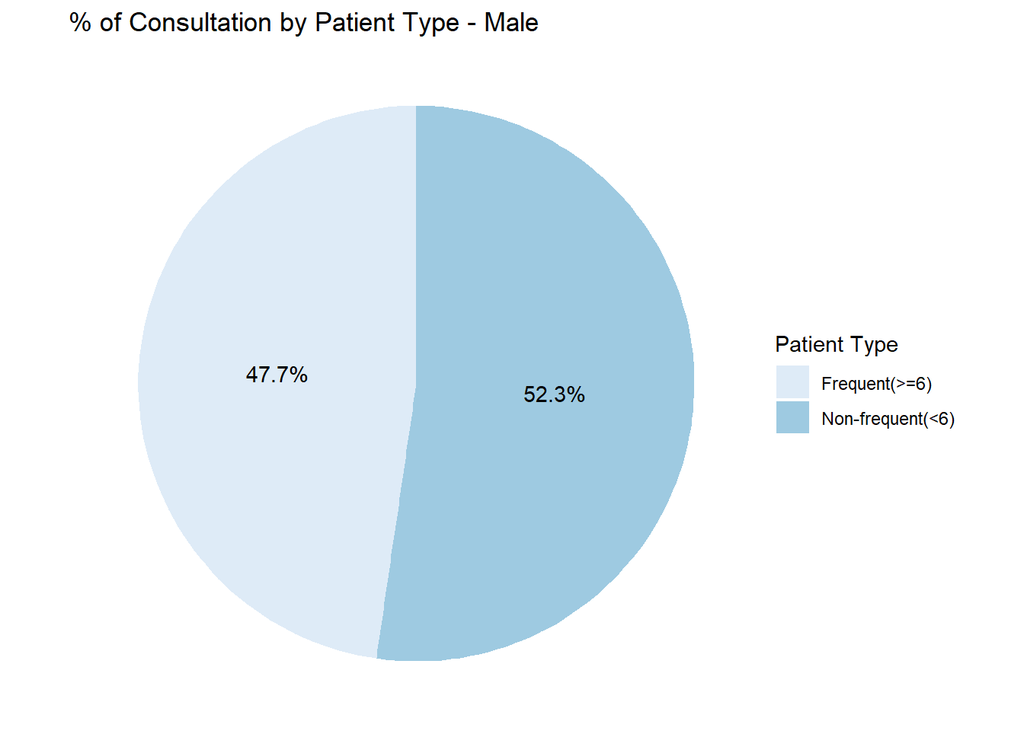

```r
patients_frequency_m %>%

  #summarize percentage of visits of frequent and non-frequent patients

  mutate(patient_type = case_when(visit_n >= 6 ~ "Frequent(>=6)",
                                  visit_n < 6 ~ "Non-frequent(<6)")) %>%

  group_by(patient_type) %>%

  summarise(pct_visit_total = sum(visit_pct),
            pct_patient_total = sum(patient_pct)) %>%

  ggplot()+

  aes(x = '',
      y = pct_visit_total,
      fill = patient_type) +

  geom_col(position = "stack") +

  scale_fill_brewer()+

  geom_text(aes(label = paste0(pct_visit_total,"%")),
            position = position_stack(vjust = 0.5)) +

  coord_polar("y")+

  theme_void()+

  theme(axis.ticks = element_blank(),
        axis.text = element_blank())+

  labs(title = "% of Consultation by Patient Type - Male",
       x = NULL, y = NULL,
       fill = "Patient Type")
```

#### 3.1.3.2 Age group

```r
#Assign patients to "Early_childhood(<8) and elderly(>65)" and "Others"

#Create a new variable to label patients
patients_n_visits_5 <-patients_n_visits_5 %>%
  mutate(age_group = case_when(age %in% (8:65) ~ "Others",
                               !age %in% (8:65) ~ "Under 8 or above 65")) %>%
  print()
```

```
## # A tibble: 1,657 × 11
##    patient_id date_of_birth gender registration_date visit_n   age cohort
##         <dbl> <date>        <chr>  <date>              <int> <dbl> <chr>
##  1     413591 1936-03-31    Female 1996-03-31             25    87 Old
##  2     449175 1996-07-25    Female 1996-11-08             25    27 Old
##  3     203029 1964-07-18    Female 2019-10-28             24    59 Old
##  4     924706 1950-12-18    Female 1996-03-31             24    73 Old
##  5     596712 1970-12-12    Female 1994-05-06             23    53 Old
##  6     390794 1984-09-11    Female 1996-03-31             21    39 Old
##  7     357148 1984-12-31    Female 2017-01-06             19    39 Old
##  8     693562 1948-11-29    Female 1998-01-15             19    75 Old
##  9     425567 1966-12-18    Male   1996-03-31             18    57 Old
## 10     617753 1976-07-17    Female 2012-05-02             16    47 Old
## # ℹ 1,647 more rows
## # ℹ 4 more variables: n_disease <dbl>, avg_time <dbl>, app_interval_int <dbl>,
## #   age_group <chr>
```

```r
#Filter data for just "Early_childhood(<8) and elderly(>65)"
patients_frequency_age <- patients_n_visits_5 %>%

  filter(age_group == "Under 8 or above 65") %>%

  #group the patients by their frequencies
  group_by(visit_n) %>%

  #count the total number of patients and visits in each group
  summarise(patient_n = n(),
            visit_total_n = sum(visit_n)) %>%

  #calculate the percentages
  mutate(patient_pct = round(patient_n/sum(patient_n)*100,2),
         visit_pct = round(visit_total_n/sum(visit_total_n)*100,2)) %>%

  #calculate the cumulative percentages
  arrange(desc(visit_n)) %>%
  mutate(patient_cumpct = cumsum(patient_pct),
         visit_cumpct = cumsum(visit_pct)) %>%

  print()
```

```
## # A tibble: 20 × 7
##    visit_n patient_n visit_total_n patient_pct visit_pct patient_cumpct
##      <int>     <int>         <int>       <dbl>     <dbl>          <dbl>
##  1      25         1            25        0.28      2.12           0.28
##  2      24         1            24        0.28      2.04           0.56
##  3      19         1            19        0.28      1.61           0.84
##  4      16         1            16        0.28      1.36           1.12
##  5      15         1            15        0.28      1.27           1.4
##  6      14         3            42        0.84      3.57           2.24
##  7      13         2            26        0.56      2.21           2.8
##  8      12         5            60        1.39      5.09           4.19
##  9      11         3            33        0.84      2.8            5.03
## 10      10         5            50        1.39      4.24           6.42
## 11       9        10            90        2.79      7.64           9.21
## 12       8        11            88        3.06      7.47          12.3
## 13       7         9            63        2.51      5.35          14.8
## 14       6        30           180        8.36     15.3           23.1
## 15       5        13            65        3.62      5.52          26.8
## 16       4        30           120        8.36     10.2           35.1
## 17       3        37           111       10.3       9.42          45.4
## 18       2        49            98       13.6       8.32          59.1
## 19       1        53            53       14.8       4.5           73.8
## 20       0        94             0       26.2       0            100.
## # ℹ 1 more variable: visit_cumpct <dbl>
```

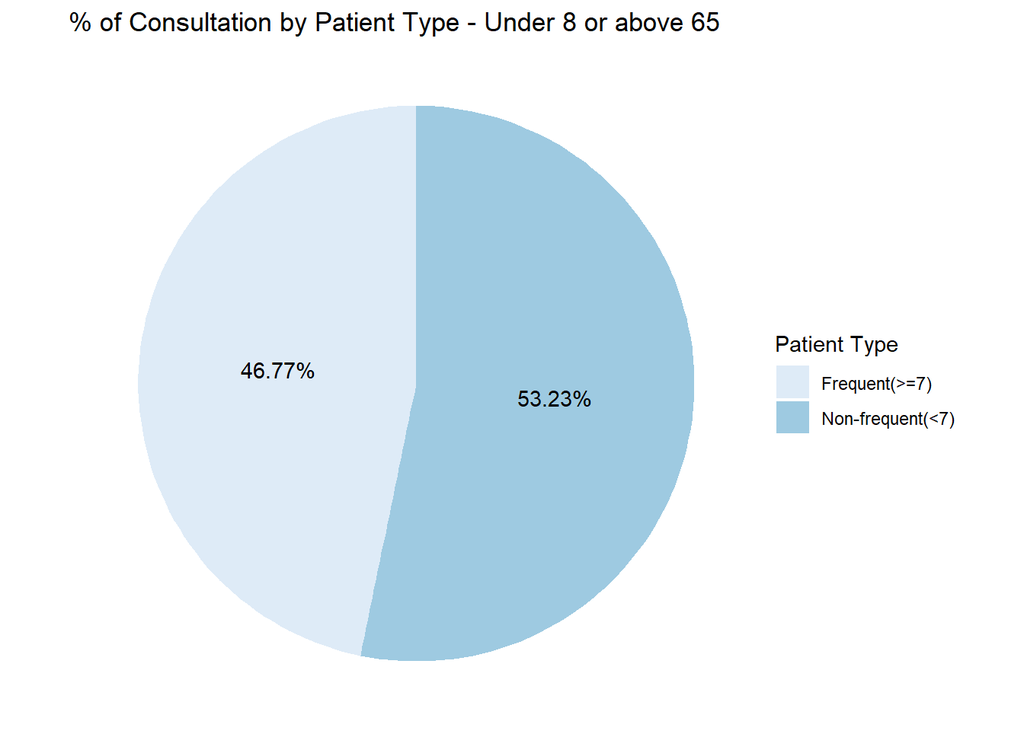

```r
patients_frequency_age %>%

  #summarize percentage of visits of frequent and non-frequent patients

  mutate(patient_type = case_when(visit_n >= 7 ~ "Frequent(>=7)",
                                  visit_n < 7 ~ "Non-frequent(<7)")) %>%

  group_by(patient_type) %>%

  summarise(pct_visit_total = sum(visit_pct),
            pct_patient_total = sum(patient_pct)) %>%

  ggplot()+

  aes(x = '',
      y = pct_visit_total,
      fill = patient_type) +

  geom_col(position = "stack") +

  scale_fill_brewer()+

  geom_text(aes(label = paste0(pct_visit_total,"%")),
            position = position_stack(vjust = 0.5)) +

  coord_polar("y")+

  theme_void()+

  theme(axis.ticks = element_blank(),
        axis.text = element_blank())+

  labs(title = "% of Consultation by Patient Type - Under 8 or above 65",
       x = NULL, y = NULL,
       fill = "Patient Type")
```

```r
#Filter data for just "others"
patients_frequency_age_o <- patients_n_visits_5 %>%

  filter(age_group == "Others") %>%

  #group the patients by their frequencies
  group_by(visit_n) %>%

  #count the total number of patients and visits in each group
  summarise(patient_n = n(),
            visit_total_n = sum(visit_n)) %>%

  #calculate the percentages
  mutate(patient_pct = round(patient_n/sum(patient_n)*100,2),
         visit_pct = round(visit_total_n/sum(visit_total_n)*100,2)) %>%

  #calculate the cumulative percentages
  arrange(desc(visit_n)) %>%
  mutate(patient_cumpct = cumsum(patient_pct),
         visit_cumpct = cumsum(visit_pct)) %>%

  print()
```

```
## # A tibble: 23 × 7
##    visit_n patient_n visit_total_n patient_pct visit_pct patient_cumpct
##      <int>     <int>         <int>       <dbl>     <dbl>          <dbl>
##  1      25         1            25        0.08      1.05           0.08
##  2      24         1            24        0.08      1.01           0.16
##  3      23         1            23        0.08      0.96           0.24
##  4      21         1            21        0.08      0.88           0.32
##  5      19         1            19        0.08      0.8            0.4
##  6      18         1            18        0.08      0.75           0.48
##  7      16         2            32        0.15      1.34           0.63
##  8      15         4            60        0.31      2.51           0.94
##  9      14         2            28        0.15      1.17           1.09
## 10      13         6            78        0.46      3.27           1.55
## # ℹ 13 more rows
## # ℹ 1 more variable: visit_cumpct <dbl>
```

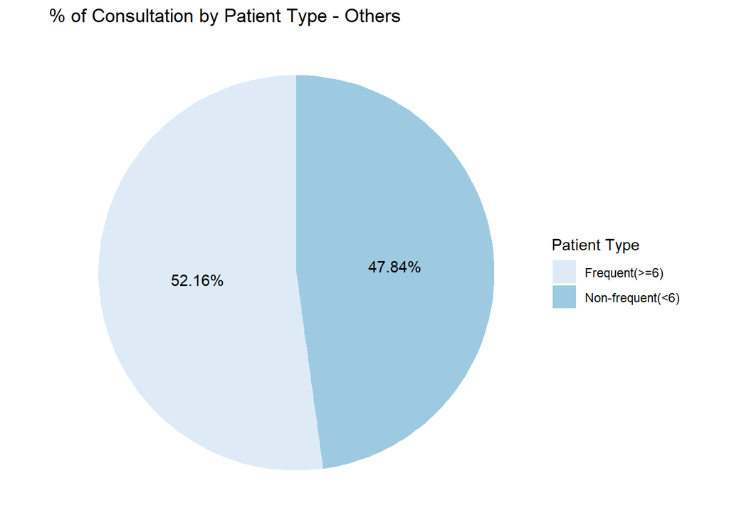

```r
patients_frequency_age_o %>%

  #summarize percentage of visits of frequent and non-frequent patients

  mutate(patient_type = case_when(visit_n >= 6 ~ "Frequent(>=6)",
                                  visit_n < 6 ~ "Non-frequent(<6)")) %>%

  group_by(patient_type) %>%

  summarise(pct_visit_total = sum(visit_pct),
            pct_patient_total = sum(patient_pct)) %>%

  ggplot()+

  aes(x = '',
      y = pct_visit_total,
      fill = patient_type) +

  geom_col(position = "stack") +

  scale_fill_brewer()+

  geom_text(aes(label = paste0(pct_visit_total,"%")),
            position = position_stack(vjust = 0.5)) +

  coord_polar("y")+

  theme_void()+

  theme(axis.ticks = element_blank(),
        axis.text = element_blank())+

  labs(title = "% of Consultation by Patient Type - Others",
       x = NULL, y = NULL,
       fill = "Patient Type")
```

#### 3.1.3.3 Chronic Disease

```r
#Filter data for just people with chronic disease
patients_frequency_disease <- patients_n_visits_5 %>%

  filter(n_disease > 0) %>%

  #group the patients by their frequencies
  group_by(visit_n) %>%

  #count the total number of patients and visits in each group
  summarise(patient_n = n(),
            visit_total_n = sum(visit_n)) %>%

  #calculate the percentages
  mutate(patient_pct = round(patient_n/sum(patient_n)*100,2),
         visit_pct = round(visit_total_n/sum(visit_total_n)*100,2)) %>%

  #calculate the cumulative percentages
  arrange(desc(visit_n)) %>%
  mutate(patient_cumpct = cumsum(patient_pct),
         visit_cumpct = cumsum(visit_pct)) %>%

  print()
```

```
## # A tibble: 20 × 7
##    visit_n patient_n visit_total_n patient_pct visit_pct patient_cumpct
##      <int>     <int>         <int>       <dbl>     <dbl>          <dbl>
##  1      25         1            25        0.22      1.36           0.22
##  2      24         2            48        0.45      2.62           0.67
##  3      23         1            23        0.22      1.25           0.89
##  4      19         1            19        0.22      1.04           1.11
##  5      15         5            75        1.12      4.09           2.23
##  6      14         3            42        0.67      2.29           2.9
##  7      13         4            52        0.89      2.84           3.79
##  8      12         5            60        1.12      3.27           4.91
##  9      11         9            99        2.01      5.4            6.92
## 10      10         9            90        2.01      4.91           8.93
## 11       9        17           153        3.8       8.35          12.7
## 12       8        19           152        4.25      8.29          17.0
## 13       7        23           161        5.15      8.78          22.1
## 14       6        34           204        7.61     11.1           29.7
## 15       5        23           115        5.15      6.27          34.9
## 16       4        43           172        9.62      9.38          44.5
## 17       3        47           141       10.5       7.69          55.0
## 18       2        72           144       16.1       7.86          71.1
## 19       1        58            58       13.0       3.16          84.1
## 20       0        71             0       15.9       0            100.
## # ℹ 1 more variable: visit_cumpct <dbl>
```

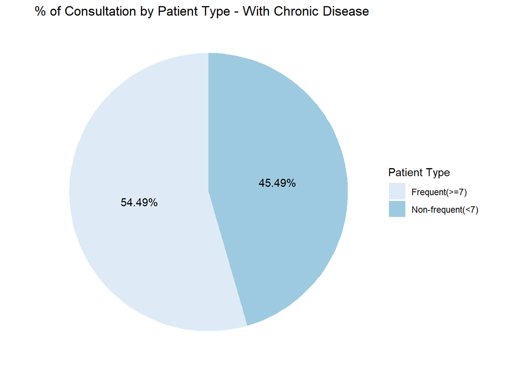

```r
patients_frequency_disease %>%

  #summarize percentage of visits of frequent and non-frequent patients

  mutate(patient_type = case_when(visit_n >= 7 ~ "Frequent(>=7)",
                                  visit_n < 7 ~ "Non-frequent(<7)")) %>%

  group_by(patient_type) %>%

  summarise(pct_visit_total = sum(visit_pct),
            pct_patient_total = sum(patient_pct)) %>%

  ggplot()+

  aes(x = '',
      y = pct_visit_total,
      fill = patient_type) +

  geom_col(position = "stack") +

  scale_fill_brewer()+

  geom_text(aes(label = paste0(pct_visit_total,"%")),
            position = position_stack(vjust = 0.5)) +

  coord_polar("y")+

  theme_void()+

  theme(axis.ticks = element_blank(),
        axis.text = element_blank())+

  labs(title = "% of Consultation by Patient Type - With Chronic Disease",
       x = NULL, y = NULL,
       fill = "Patient Type")
```

```r
#Filter data for just people without chronic disease
patients_frequency_disease <- patients_n_visits_5 %>%

  filter(n_disease == 0) %>%

  #group the patients by their frequencies
  group_by(visit_n) %>%

  #count the total number of patients and visits in each group
  summarise(patient_n = n(),
            visit_total_n = sum(visit_n)) %>%

  #calculate the percentages
  mutate(patient_pct = round(patient_n/sum(patient_n)*100,2),
         visit_pct = round(visit_total_n/sum(visit_total_n)*100,2)) %>%

  #calculate the cumulative percentages
  arrange(desc(visit_n)) %>%
  mutate(patient_cumpct = cumsum(patient_pct),
         visit_cumpct = cumsum(visit_pct)) %>%

  print()
```

```
## # A tibble: 20 × 7
##    visit_n patient_n visit_total_n patient_pct visit_pct patient_cumpct
##      <int>     <int>         <int>       <dbl>     <dbl>          <dbl>
##  1      25         1            25        0.08      1.44           0.08
##  2      21         1            21        0.08      1.21           0.16
##  3      19         1            19        0.08      1.1            0.24
##  4      18         1            18        0.08      1.04           0.32
##  5      16         3            48        0.25      2.77           0.57
##  6      14         2            28        0.17      1.62           0.74
##  7      13         4            52        0.33      3              1.07
##  8      12         4            48        0.33      2.77           1.4
##  9      11         4            44        0.33      2.54           1.73
## 10      10         7            70        0.58      4.04           2.31
## 11       9         8            72        0.66      4.16           2.97
## 12       8         8            64        0.66      3.7            3.63
## 13       7        18           126        1.49      7.27           5.12
## 14       6        23           138        1.9       7.97           7.02
## 15       5        33           165        2.73      9.53           9.75
## 16       4        52           208        4.3      12.0           14.0
## 17       3        75           225        6.2      13.0           20.2
## 18       2       112           224        9.26     12.9           29.5
## 19       1       137           137       11.3       7.91          40.8
## 20       0       716             0       59.2       0            100
## # ℹ 1 more variable: visit_cumpct <dbl>
```

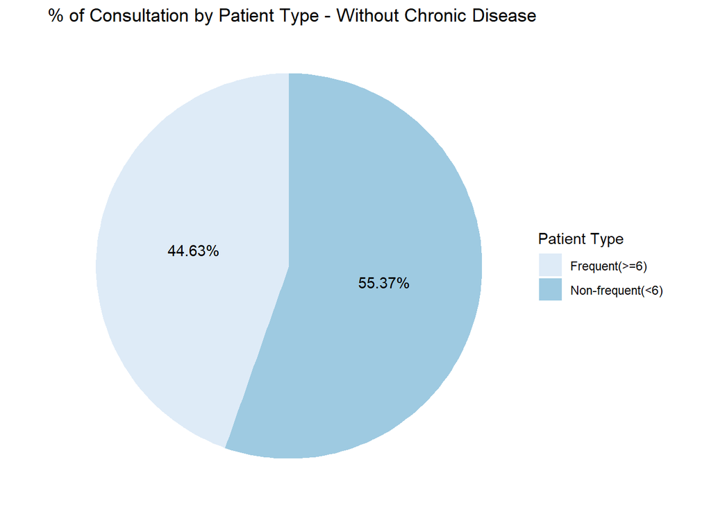

```r
patients_frequency_disease %>%

  #summarize percentage of visits of frequent and non-frequent patients

  mutate(patient_type = case_when(visit_n >= 6 ~ "Frequent(>=6)",
                                  visit_n < 6 ~ "Non-frequent(<6)")) %>%

  group_by(patient_type) %>%

  summarise(pct_visit_total = sum(visit_pct),
            pct_patient_total = sum(patient_pct)) %>%

  ggplot()+

  aes(x = '',
      y = pct_visit_total,
      fill = patient_type) +

  geom_col(position = "stack") +

  scale_fill_brewer()+

  geom_text(aes(label = paste0(pct_visit_total,"%")),
            position = position_stack(vjust = 0.5)) +

  coord_polar("y")+

  theme_void()+

  theme(axis.ticks = element_blank(),
        axis.text = element_blank())+

  labs(title = "% of Consultation by Patient Type - Without Chronic Disease",
       x = NULL, y = NULL,
       fill = "Patient Type")
```

#### 3.1.3.4 Registration Cohort

```r
#Filter data for just people in the "New" cohort
patients_frequency_cohort <- patients_n_visits_5 %>%

  filter(cohort == "New") %>%

  #group the patients by their frequencies
  group_by(visit_n) %>%

  #count the total number of patients and visits in each group
  summarise(patient_n = n(),
            visit_total_n = sum(visit_n)) %>%

  #calculate the percentages
  mutate(patient_pct = round(patient_n/sum(patient_n)*100,2),
         visit_pct = round(visit_total_n/sum(visit_total_n)*100,2)) %>%

  #calculate the cumulative percentages
  arrange(desc(visit_n)) %>%
  mutate(patient_cumpct = cumsum(patient_pct),
         visit_cumpct = cumsum(visit_pct)) %>%

  print()
```

```
## # A tibble: 5 × 7
##   visit_n patient_n visit_total_n patient_pct visit_pct patient_cumpct
##     <int>     <int>         <int>       <dbl>     <dbl>          <dbl>
## 1       4         1             4        0.28     11.1            0.28
## 2       3         1             3        0.28      8.33           0.56
## 3       2         6            12        1.68     33.3            2.24
## 4       1        17            17        4.75     47.2            6.99
## 5       0       333             0       93.0       0            100.
## # ℹ 1 more variable: visit_cumpct <dbl>
```

```r
#Filter data for just people in the "New" cohort
patients_frequency_cohort_old <- patients_n_visits_5 %>%

  filter(cohort == "Old") %>%

  #group the patients by their frequencies
  group_by(visit_n) %>%

  #count the total number of patients and visits in each group
  summarise(patient_n = n(),
            visit_total_n = sum(visit_n)) %>%

  #calculate the percentages
  mutate(patient_pct = round(patient_n/sum(patient_n)*100,2),
         visit_pct = round(visit_total_n/sum(visit_total_n)*100,2)) %>%

  #calculate the cumulative percentages
  arrange(desc(visit_n)) %>%
  mutate(patient_cumpct = cumsum(patient_pct),
         visit_cumpct = cumsum(visit_pct)) %>%

  print()
```

```
## # A tibble: 23 × 7
##    visit_n patient_n visit_total_n patient_pct visit_pct patient_cumpct
##      <int>     <int>         <int>       <dbl>     <dbl>          <dbl>
##  1      25         2            50        0.15      1.42           0.15
##  2      24         2            48        0.15      1.36           0.3
##  3      23         1            23        0.08      0.65           0.38
##  4      21         1            21        0.08      0.6            0.46
##  5      19         2            38        0.15      1.08           0.61
##  6      18         1            18        0.08      0.51           0.69
##  7      16         3            48        0.23      1.36           0.92
##  8      15         5            75        0.38      2.13           1.3
##  9      14         5            70        0.38      1.98           1.68
## 10      13         8           104        0.62      2.95           2.3
## # ℹ 13 more rows
## # ℹ 1 more variable: visit_cumpct <dbl>
```

As we can see, new cohort does not appears to behave as the 10%-50% pattern we discussed before, and 93% of the patients haven’t visited GP, therefore, we only filter for old cohort to find inappropriate usage.

## 3.2 Filter for frequent patient

```r
patients_oldco <- patients_n_visits_5 %>%

  #Filter only for old cohort
  filter(cohort == "Old") %>%

  print()
```

```
## # A tibble: 1,299 × 11
##    patient_id date_of_birth gender registration_date visit_n   age cohort
##         <dbl> <date>        <chr>  <date>              <int> <dbl> <chr>
##  1     413591 1936-03-31    Female 1996-03-31             25    87 Old
##  2     449175 1996-07-25    Female 1996-11-08             25    27 Old
##  3     203029 1964-07-18    Female 2019-10-28             24    59 Old
##  4     924706 1950-12-18    Female 1996-03-31             24    73 Old
##  5     596712 1970-12-12    Female 1994-05-06             23    53 Old
##  6     390794 1984-09-11    Female 1996-03-31             21    39 Old
##  7     357148 1984-12-31    Female 2017-01-06             19    39 Old
##  8     693562 1948-11-29    Female 1998-01-15             19    75 Old
##  9     425567 1966-12-18    Male   1996-03-31             18    57 Old
## 10     617753 1976-07-17    Female 2012-05-02             16    47 Old
## # ℹ 1,289 more rows
## # ℹ 4 more variables: n_disease <dbl>, avg_time <dbl>, app_interval_int <dbl>,
## #   age_group <chr>
```

Now we filter for frequent patients in vulnerable groups, using the 7-times-visit criteria.

```r
patients_oldco_vul <- patients_oldco %>%

  #filter vulnerable groups
  filter(gender == "Female"
  | age_group == "Under 8 or above 65"
  | n_disease > 0) %>%

  #filter for frequent patient
  filter(visit_n >= 7) %>%

  print()
```

```
## # A tibble: 142 × 11
##    patient_id date_of_birth gender registration_date visit_n   age cohort
##         <dbl> <date>        <chr>  <date>              <int> <dbl> <chr>
##  1     413591 1936-03-31    Female 1996-03-31             25    87 Old
##  2     449175 1996-07-25    Female 1996-11-08             25    27 Old
##  3     203029 1964-07-18    Female 2019-10-28             24    59 Old
##  4     924706 1950-12-18    Female 1996-03-31             24    73 Old
##  5     596712 1970-12-12    Female 1994-05-06             23    53 Old
##  6     390794 1984-09-11    Female 1996-03-31             21    39 Old
##  7     357148 1984-12-31    Female 2017-01-06             19    39 Old
##  8     693562 1948-11-29    Female 1998-01-15             19    75 Old
##  9     617753 1976-07-17    Female 2012-05-02             16    47 Old
## 10     668889 2021-07-20    Female 2021-08-23             16     2 Old
## # ℹ 132 more rows
## # ℹ 4 more variables: n_disease <dbl>, avg_time <dbl>, app_interval_int <dbl>,
## #   age_group <chr>
```

Now we filter for frequent patients in none-vulnerable groups, using the 6-times-visit criteria.

```r
patients_oldco_nonevul <- patients_oldco %>%

  filter(gender == "Male"
  & age_group == "Others"
  & n_disease == 0) %>%

  #filter for frequent patient
  filter(visit_n >= 6) %>%

  print()
```

```
## # A tibble: 22 × 11
##    patient_id date_of_birth gender registration_date visit_n   age cohort
##         <dbl> <date>        <chr>  <date>              <int> <dbl> <chr>
##  1     425567 1966-12-18    Male   1996-03-31             18    57 Old
##  2     199453 1987-01-01    Male   2016-01-15             12    36 Old
##  3     326281 1966-08-24    Male   2021-10-25             11    57 Old
##  4      79844 1988-04-26    Male   2003-11-11             10    35 Old
##  5     256017 1980-09-01    Male   2017-03-14              9    43 Old
##  6     516919 1966-12-28    Male   2007-10-31              9    57 Old
##  7     671893 1972-08-22    Male   2023-02-08              9    51 Old
##  8      52500 1994-05-03    Male   2017-01-04              8    29 Old
##  9     116059 1994-09-03    Male   2019-12-12              8    29 Old
## 10     791205 1976-01-28    Male   2011-05-16              8    47 Old
## # ℹ 12 more rows
## # ℹ 4 more variables: n_disease <dbl>, avg_time <dbl>, app_interval_int <dbl>,
## #   age_group <chr>
```

We have a total of 142+22=164 patients. We now look at their appointment patterns to find the top 50 that are most likely to use GP inappropriately.

## 3.3 Identify inappropriate usage

Filter out the patients using the following features.

```
Features include:
```

- Shorter average planned time;
- Shorter Intervals between appointments;

```r
# first for vulnerable patients
patients_oldco_vul_sus <- patients_oldco_vul %>%

  # Shorter average planned time
  filter(avg_time<quantile(avg_time, 0.5) |
         # Shorter Intervals between appointments
         app_interval_int<quantile(app_interval_int, 0.5)) %>%

  print()
```

```
## # A tibble: 108 × 11
##    patient_id date_of_birth gender registration_date visit_n   age cohort
##         <dbl> <date>        <chr>  <date>              <int> <dbl> <chr>
##  1     413591 1936-03-31    Female 1996-03-31             25    87 Old
##  2     449175 1996-07-25    Female 1996-11-08             25    27 Old
##  3     203029 1964-07-18    Female 2019-10-28             24    59 Old
##  4     924706 1950-12-18    Female 1996-03-31             24    73 Old
##  5     596712 1970-12-12    Female 1994-05-06             23    53 Old
##  6     390794 1984-09-11    Female 1996-03-31             21    39 Old
##  7     357148 1984-12-31    Female 2017-01-06             19    39 Old
##  8     693562 1948-11-29    Female 1998-01-15             19    75 Old
##  9     617753 1976-07-17    Female 2012-05-02             16    47 Old
## 10     668889 2021-07-20    Female 2021-08-23             16     2 Old
## # ℹ 98 more rows
## # ℹ 4 more variables: n_disease <dbl>, avg_time <dbl>, app_interval_int <dbl>,
## #   age_group <chr>
```

Usually, the most vulnerable groups (people in under 8 and above 65 age groups and with chronic diseases) in are less likely to use GP inappropriately. So we try to filter them out.

```r
patients_oldco_vul_sus_1 <- patients_oldco_vul_sus %>%
  filter(age_group != "Under 8 or above 65" & n_disease == 0) %>%
  print()
```

```
## # A tibble: 29 × 11
##    patient_id date_of_birth gender registration_date visit_n   age cohort
##         <dbl> <date>        <chr>  <date>              <int> <dbl> <chr>
##  1     449175 1996-07-25    Female 1996-11-08             25    27 Old
##  2     390794 1984-09-11    Female 1996-03-31             21    39 Old
##  3     357148 1984-12-31    Female 2017-01-06             19    39 Old
##  4     617753 1976-07-17    Female 2012-05-02             16    47 Old
##  5     818746 1984-10-28    Female 2021-06-02             16    39 Old
##  6     287807 1969-07-20    Female 1996-03-31             14    54 Old
##  7     925346 2005-05-06    Female 2005-07-06             14    18 Old
##  8     639942 1986-06-14    Female 2005-03-07             13    37 Old
##  9     733389 1993-02-07    Female 2022-01-25             13    30 Old
## 10     783803 1962-10-30    Female 1996-03-31             13    61 Old
## # ℹ 19 more rows
## # ℹ 4 more variables: n_disease <dbl>, avg_time <dbl>, app_interval_int <dbl>,
## #   age_group <chr>
```

```r
# then for none-vulnerable patients
patients_oldco_nonevul_sus <- patients_oldco_nonevul %>%

  # Shorter average planned time
  filter(avg_time<quantile(avg_time, 0.5) |
         # Shorter Intervals between appointments
         app_interval_int<quantile(app_interval_int, 0.5)) %>%

  print()
```

```
## # A tibble: 17 × 11
##    patient_id date_of_birth gender registration_date visit_n   age cohort
##         <dbl> <date>        <chr>  <date>              <int> <dbl> <chr>
##  1     425567 1966-12-18    Male   1996-03-31             18    57 Old
##  2     199453 1987-01-01    Male   2016-01-15             12    36 Old
##  3     326281 1966-08-24    Male   2021-10-25             11    57 Old
##  4     671893 1972-08-22    Male   2023-02-08              9    51 Old
##  5      52500 1994-05-03    Male   2017-01-04              8    29 Old
##  6     116059 1994-09-03    Male   2019-12-12              8    29 Old
##  7     791205 1976-01-28    Male   2011-05-16              8    47 Old
##  8     845781 1979-02-21    Male   2006-08-25              8    44 Old
##  9     924918 1997-12-24    Male   2017-04-03              8    26 Old
## 10     131518 1968-10-14    Male   2022-09-06              7    55 Old
## 11     169071 1975-06-17    Male   2016-05-06              7    48 Old
## 12     307510 1970-02-21    Male   1996-03-31              7    53 Old
## 13     644108 2006-04-23    Male   2006-05-16              7    17 Old
## 14     722477 1991-03-15    Male   1996-03-31              7    32 Old
## 15     769392 1984-07-05    Male   1996-03-31              7    39 Old
## 16     731668 1986-01-31    Male   2016-02-05              6    37 Old
## 17     877220 1991-08-08    Male   2021-08-16              6    32 Old
## # ℹ 4 more variables: n_disease <dbl>, avg_time <dbl>, app_interval_int <dbl>,
## #   age_group <chr>
```

Now we have a total of 29+17=46 patients. We merge the two tables to get the top patients that are likely to use GP appropriately.

```r
final_patient_list <- rbind(patients_oldco_nonevul_sus,
                            patients_oldco_vul_sus_1) %>%
  print()
```

```
## # A tibble: 46 × 11
##    patient_id date_of_birth gender registration_date visit_n   age cohort
##         <dbl> <date>        <chr>  <date>              <int> <dbl> <chr>
##  1     425567 1966-12-18    Male   1996-03-31             18    57 Old
##  2     199453 1987-01-01    Male   2016-01-15             12    36 Old
##  3     326281 1966-08-24    Male   2021-10-25             11    57 Old
##  4     671893 1972-08-22    Male   2023-02-08              9    51 Old
##  5      52500 1994-05-03    Male   2017-01-04              8    29 Old
##  6     116059 1994-09-03    Male   2019-12-12              8    29 Old
##  7     791205 1976-01-28    Male   2011-05-16              8    47 Old
##  8     845781 1979-02-21    Male   2006-08-25              8    44 Old
##  9     924918 1997-12-24    Male   2017-04-03              8    26 Old
## 10     131518 1968-10-14    Male   2022-09-06              7    55 Old
## # ℹ 36 more rows
## # ℹ 4 more variables: n_disease <dbl>, avg_time <dbl>, app_interval_int <dbl>,
## #   age_group <chr>
```

```r
#save the tibble as an excel
#write.xlsx(final_patient_list, "final_patient_list.xlsx")
```